# Fantasy ChampMan Raw Data up to Gameweek 26

### Chart(s) and raw data tables and for FantasyChampMan data fans. From goals scored to key tackles and more! Credits to FantasyChampMan for creating the wonderful game. Author: LordyLeroy.

For best results on mobile browsers, please enable desktop site. Data generated from analysis of screenshots using a mixture of [OCR](https://opensource.google/projects/tesseract), [image processing](https://imagemagick.org/index.php), and points updates from FPL_Panda. Please [let me know](https://twitter.com/LordyLeroy) if you have any feedback or identify any errors! The data is searchable, filterable, sortable, and downloadable.

## Chart(s) and Data Tables

### Key Contributions - Chart

**Description**: Leaders in Key Contributions in Gameweek 26.

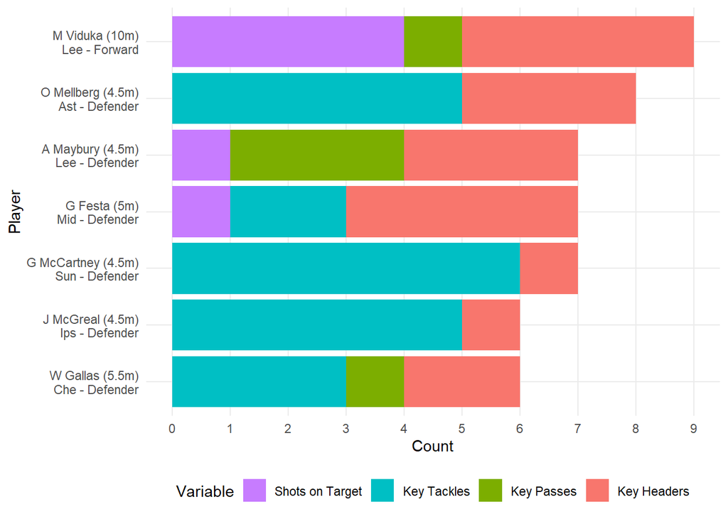

### Points (Gameweek 26) - Table

**Description**: Points scoring variables: Points Scored, Player Rating, Saves, Goals Conceded, Bonus Points, Assists, Goals Scored, Clean Sheets, Own Goals, Red Cards, Yellow Cards, Penalties Missed, Penalties Saved.

Please note that data for Double Gameweeks are separated out by match.

| Player | Player Value (£m) | Position | Club | Home or Away | Variable | Value |
| --- | --- | --- | --- | --- | --- | --- |
| S Selakovic | 8 | Midfielder | Tot | Away | Points Scored | 15 |
| R Lee | 5 | Midfielder | Bol | Home | Points Scored | 13 |
| M Forssell | 5 | Forward | Che | Home | Points Scored | 13 |
| J F Hasselbaink | 10.5 | Forward | Che | Home | Points Scored | 11 |
| G Kelly | 4.5 | Defender | Lee | Away | Points Scored | 11 |
| A Maybury | 4.5 | Defender | Lee | Away | Points Scored | 11 |
| R Giggs | 11 | Midfielder | Mun | Home | Points Scored | 11 |
| T Sheringham | 7.5 | Forward | Tot | Away | Points Scored | 11 |
| G Kelly | 4.5 | Defender | Lee | Away | Player Rating | 10 |
| G Festa | 5 | Defender | Mid | Home | Points Scored | 10 |

[output cut: 1895 more lines]

### Points (All Gameweeks) - Table

**Description**: Points scoring variables: Points Scored, Saves, Goals Conceded, Bonus Points, Goals Scored, Clean Sheets, Assists, Av. Player Rating, Yellow Cards, Penalties Saved, Red Cards, Penalties Missed, Own Goals.

| Player | Player Value (£m) | Position | Club | Variable | Value |
| --- | --- | --- | --- | --- | --- |
| M Viduka | 10 | Forward | Lee | Points Scored | 156 |
| R Van Nistelrooy | 13 | Forward | Mun | Points Scored | 156 |
| A Johnston | 7 | Midfielder | Mid | Points Scored | 137 |
| K Phillips | 9.5 | Forward | Sun | Points Scored | 133 |
| T Henry | 13 | Forward | Ars | Points Scored | 128 |
| G Festa | 5 | Defender | Mid | Points Scored | 126 |
| L Boa Morte | 8.5 | Midfielder | Ful | Points Scored | 125 |
| J Scowcroft | 8 | Midfielder | Lei | Points Scored | 120 |
| H Pedersen | 7.5 | Forward | Bol | Points Scored | 119 |
| J Wilcox | 5.5 | Midfielder | Cha | Points Scored | 117 |

[output cut: 4991 more lines]

### Statistics - Table

**Description**: Match statistics variables: Minutes Played, Passes Attempted, Passes Completed, Headers Attempted, Shots Attempted, Shots on Target, Headers Won, Key Headers, Condition, Key Passes, Tackles Attempted, Tackles Won, Key Tackles.

Gameweeks 22 to 26. Values of zero are excluded for all variables (except Condition) for speed purposes. Condition is shown for Gameweek 26 only and is the condition post match.

Please note that data for Double Gameweeks are separated out by match.

| Gameweek | Player | Player Value (£m) | Position | Club | Home or Away | Variable | Value |
| --- | --- | --- | --- | --- | --- | --- | --- |
| 23 | A Akinbiyi | 6.5 | Forward | Lei | Home | Minutes Played | 23 |
| 23 | A Akinbiyi | 6.5 | Forward | Lei | Home | Passes Attempted | 9 |
| 23 | A Akinbiyi | 6.5 | Forward | Lei | Home | Passes Completed | 7 |
| 23 | A Akinbiyi | 6.5 | Forward | Lei | Home | Headers Attempted | 3 |
| 23 | A Akinbiyi | 6.5 | Forward | Lei | Home | Shots Attempted | 2 |
| 23 | A Akinbiyi | 6.5 | Forward | Lei | Home | Shots on Target | 2 |
| 23 | A Akinbiyi | 6.5 | Forward | Lei | Home | Headers Won | 1 |
| 23 | A Akinbiyi | 6.5 | Forward | Lei | Home | Key Headers | 1 |
| 23 | A Armstrong | 5 | Forward | Ips | Away | Minutes Played | 70 |
| 26 | A Armstrong | 5 | Forward | Ips | Home | Condition | 64 |

[output cut: 8724 more lines]